# Unemployment

Tom

2023-10-14

# Intro

This analysis delves into US unemployment data, focusing on two key aspects: disparities in unemployment rates by race and gender, and the impact of educational level, particularly possessing a bachelor’s degree, on these rates.

We examine racial disparities among Black, White, and Hispanic individuals and explore gender differences, considering education levels. Our goal is to offer a comprehensive understanding of US unemployment trends, using visualizations to highlight variations among demographic categories and the influence of education on employment prospects.

In summary, this analysis sheds light on disparities and factors influencing unemployment rates, aiding informed discussions and evidence-based policymaking in the dynamic labor market.

# Loading the Data

To begin, load the following R packages: ggplot2, tidyverse, and readr. Then enter your file path to read the included CSV file into your R environment.

```r
library(ggplot2)
library(tidyverse)
library(readr)
library(cowplot)
library(dplyr)
library(scales)
usunemployment <- read.csv("/Users/tomascontreras/Documents/codingthings/SQL + Datasets/unemployed_population_1978-12_to_2023-07.csv")
```

# Comparing Gender and Bachelor’s Degree Impact on Unemployment Rates

In this section, we conduct a comprehensive exploration of unemployment rates, with a specific focus on gender disparities and the impact of educational attainment. The first chart scrutinizes the dynamic trends in unemployment rates between men and women over time, revealing valuable insights into gender-specific employment dynamics.

To deepen our understanding of these gender-driven dynamics, the second chart zooms in on unemployment rates for men and women with bachelor’s degrees. This analysis uncovers how educational attainment intersects with gender to shape employment prospects, providing nuanced insights into the complex relationship between education and gender in the labor market. These visualizations shed light on the multifaceted factors influencing unemployment rates and offer valuable input for gender-equity-focused policies and strategies in the labor market.

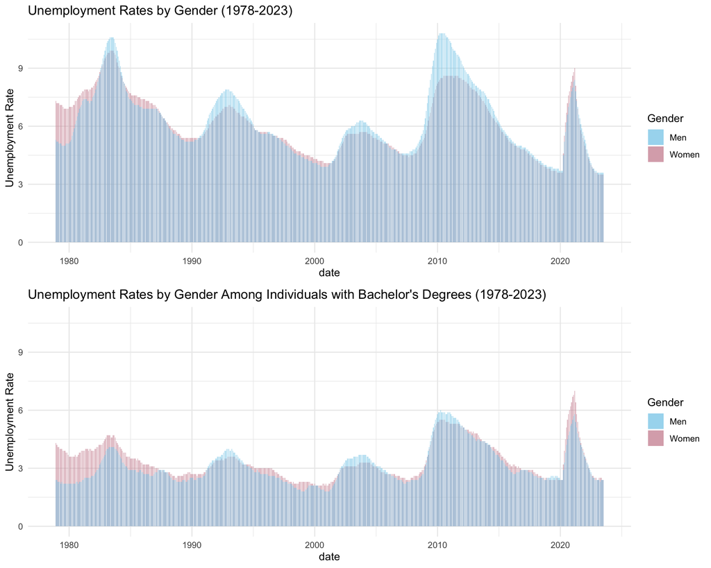

```r
# Set the width and height of the individual plots
plot_width <- 8  # Adjust as needed
plot_height <- 4  # Adjust as needed

# Select the relevant columns and convert the date column to Date format for gender data
usunemployment_men_women <- usunemployment %>%
  select(date, women, men) %>%
  mutate(date = as.Date(date))

# Create the bar chart for gender unemployment rates
gg_men_women <- ggplot(usunemployment_men_women, aes(x = date)) +
  geom_bar(aes(y = women, fill = "Women"), stat = "identity", position = "dodge", alpha = 0.5) +
  geom_bar(aes(y = men, fill = "Men"), stat = "identity", position = "dodge", alpha = 0.5) +
  scale_fill_manual(values = c("Men" = "skyblue", "Women" = "pink3")) +
  labs(y = "Unemployment Rate", fill = "Gender") +
  theme_minimal() +
  labs(title = "Unemployment Rates by Gender (1978-2023)")

# Select the relevant columns and convert the date column to Date format for gender and bachelor's degree data
usunemployment_men_women_bach <- usunemployment %>%
  select(date, women_bachelor.s_degree, men_bachelor.s_degree) %>%
  mutate(date = as.Date(date))

# Create the bar chart for gender and bachelor's degree unemployment rates
gg_men_women_bach <- ggplot(usunemployment_men_women_bach, aes(x = date)) +
  geom_bar(aes(y = women_bachelor.s_degree, fill = "Women"), stat = "identity", position = "dodge", alpha = 0.5) +
  geom_bar(aes(y = men_bachelor.s_degree, fill = "Men"), stat = "identity", position = "dodge", alpha = 0.5) +
  scale_fill_manual(values = c("Men" = "skyblue", "Women" = "pink3")) +
  labs(y = "Unemployment Rate", fill = "Gender") +
  theme_minimal() +
  labs(title = "Unemployment Rates by Gender Among Individuals with Bachelor's Degrees (1978-2023)")

# Calculate the maximum Y-axis value for both plots
max_value <- max(
  max(usunemployment_men_women$women, usunemployment_men_women$men),
  max(usunemployment_men_women_bach$women_bachelor.s_degree, usunemployment_men_women_bach$men_bachelor.s_degree)
)

# Set Y-axis limits for both plots
gg_men_women <- gg_men_women + ylim(0, max_value)
gg_men_women_bach <- gg_men_women_bach + ylim(0, max_value)

# Combine the two plots one above the other
combined_plot <- plot_grid(gg_men_women, gg_men_women_bach, ncol = 1, align = "v", rel_heights = c(1, 1))

# Set the width and height of the combined plot
plot_new_width <- plot_width
plot_new_height <- plot_height * 2  # Double the height for stacking vertically

# Display the combined plot with the adjusted width and height
options(repr.plot.width = plot_new_width, repr.plot.height = plot_new_height)
print(combined_plot)
```

# Comparison of Unemployment Rates by Race and Among Individuals with Bachelor’s Degrees

These visualizations provide an in-depth examination of unemployment trends within Black, White, and Hispanic communities. The upper chart offers a comprehensive view of general trends in unemployment rates among these demographic groups. In contrast, the lower chart narrows the focus to individuals holding bachelor’s degrees, specifically illuminating the interplay between education and unemployment rates within these racial categories. By maintaining consistent Y-axis limits for effective comparison, both charts shed light on the complex dynamics of employment disparities within these racial demographics, particularly emphasizing the significant influence of educational attainment on unemployment rates.

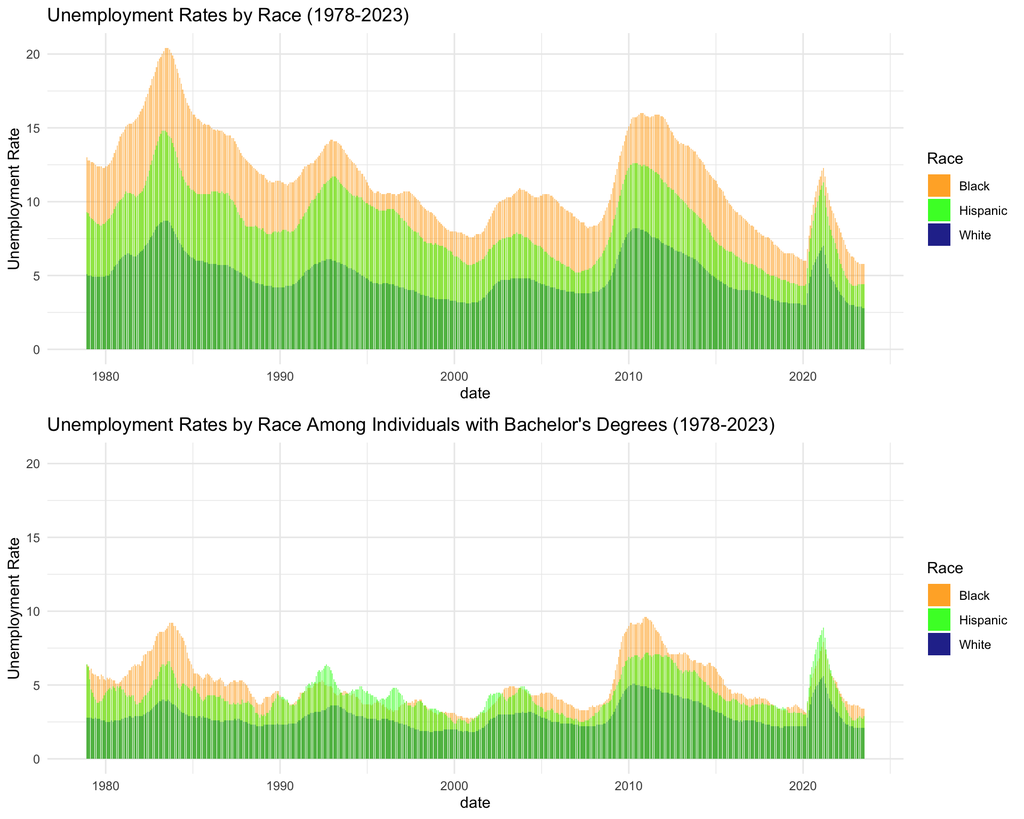

```r
# Plot 1: Unemployment Rates by Race
usunemployment_black_white <- usunemployment %>%
  select(date, black, white, hispanic) %>%
  mutate(date = as.Date(date))

# Calculate the max Y-axis value for both plots
max_value <- max(
  max(usunemployment_black_white$black),
  max(usunemployment_black_white$white),
  max(usunemployment_black_white$hispanic)
)

plot1 <- ggplot(usunemployment_black_white, aes(x = date)) +
  geom_bar(aes(y = black, fill = "Black"), stat = "identity", position = "dodge", alpha = 0.5) +
  geom_bar(aes(y = white, fill = "White"), stat = "identity", position = "dodge", alpha = 0.5) +
  geom_bar(aes(y = hispanic, fill = "Hispanic"), stat = "identity", position = "dodge", alpha = 0.5) +
  scale_fill_manual(values = c("Black" = "orange", "White" = "blue4", "Hispanic" = "green")) +
  labs(y = "Unemployment Rate", fill = "Race") +
  labs(title = "Unemployment Rates by Race (1978-2023)") +
  theme_minimal() +
  ylim(0, max_value)  # Set Y-axis limits

# Plot 2: Unemployment Rates by Race Among Individuals with Bachelor's Degrees
usunemployment_black_white_hisp_bach <- usunemployment %>%
  select(date, black_bachelor.s_degree, white_bachelor.s_degree, hispanic_bachelor.s_degree) %>%
  mutate(date = as.Date(date))

plot2 <- ggplot(usunemployment_black_white_hisp_bach, aes(x = date)) +
  geom_bar(aes(y = black_bachelor.s_degree, fill = "Black"), stat = "identity", position = "dodge", alpha = 0.5) +
  geom_bar(aes(y = white_bachelor.s_degree, fill = "White"), stat = "identity", position = "dodge", alpha=0.5) +
  geom_bar(aes(y = hispanic_bachelor.s_degree, fill = "Hispanic"), stat = "identity", position = "dodge", alpha=0.5) +
  scale_fill_manual(values = c("Black" = "orange", "White" = "blue4", "Hispanic"="green")) +
  labs(y = "Unemployment Rate", fill = "Race") +
  labs(title = "Unemployment Rates by Race Among Individuals with Bachelor's Degrees (1978-2023)") +
  theme_minimal() +
  ylim(0, max_value)  # Set Y-axis limits

# Combine plots vertically using cowplot
combined_plot <- plot_grid(plot1, plot2, ncol = 1)

# Print the combined plot
combined_plot
```

# Analyzing Deviations from the Overall Average Unemployment Rate

The graph presented here serves as a visual guide, shedding light on how the average unemployment rate among diverse demographic categories deviates from the overarching average unemployment rate. As we delve into this analysis, it’s important to keep in mind that this data spans from 1978 to 2023, offering a broad temporal perspective. This visualization provides a dynamic insight into the nuanced patterns of unemployment rates, offering a comparative lens to observe how different demographic groups fare in relation to the overall employment landscape. By examining these variations, we can uncover trends, disparities, and influential factors that inform labor market policies and decisions. This exploration aims to contribute to a comprehensive understanding of US unemployment trends, particularly in the context of race, gender, and educational attainment, and thereby foster meaningful discussions, data-driven policymaking, and inspire further research in the field.

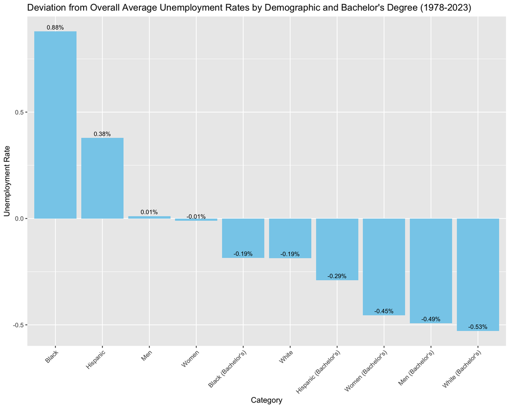

```r
data <- data.frame(
  Category = c("Men", "Women", "White", "Hispanic", "Black", "Men (Bachelor's)", "Women (Bachelor's)", "White (Bachelor's)", "Hispanic (Bachelor's)", "Black (Bachelor's)"),
  Value = c(diff_avg_men, diff_avg_women, diff_avg_white, diff_avg_hispanic, diff_avg_black, diff_avg_men_bach, diff_avg_women_bach, diff_avg_white_bach, diff_avg_hispanic_bach, diff_avg_black_bach)
) %>%
  arrange(desc(Value))  # Sort the data frame by "Value" in descending order

# Create the bar graph
bar_plot <- ggplot(data, aes(x = reorder(Category, -Value), y = Value)) +
  geom_bar(stat = "identity", fill = "skyblue") +
  geom_text(aes(label = sprintf("%.2f%%", Value)), vjust = -0.5, size = 3) +
  labs(title = "Deviation from Overall Average Unemployment Rates by Demographic and Bachelor's Degree (1978-2023)") +
  xlab("Category") +
  ylab("Unemployment Rate") +
  theme(axis.text.x = element_text(angle = 45, hjust = 1))

# Print the bar_plot
print(bar_plot)
```

# Conclusion

In this analysis, we’ve delved into US unemployment data, focusing on two pivotal dimensions: unemployment rates categorized by race and gender, and the influence of educational attainment, specifically the possession of a bachelor’s degree, on these rates.

[output not shown]

These visualizations help us understand how different demographic factors, such as race and gender, can impact unemployment rates. The data presented here highlights the importance of considering these factors when analyzing labor market trends and making informed decisions related to workforce policies and opportunities.

Overall, these insights contribute to a better understanding of the complex dynamics of unemployment in the United States, and they underscore the need for continued efforts to address disparities in employment opportunities across different demographic groups.

# References

- [Economic Policy Institute, State of Working America Data Library, “Unemployment,” 2023](https://www.epi.org/data/)
- Population Sample (Civilian noninstitutional population): The civilian noninstitutional population consists of people 16 years old and older residing in the 50 states and the District of Columbia who are not on active duty in the Armed Forces or living in institutions (such as correctional facilities or nursing homes).